# Analysis and Prediction of Employee Attrition.

```r
length(emp_df$NumCompaniesWorked[emp_df$NumCompaniesWorked==9])
```

```
[1] 52
```

There are total of 52 records with Number of Companies Worked as 9. Droping this record may not be a wise choice. They need to be transformed.

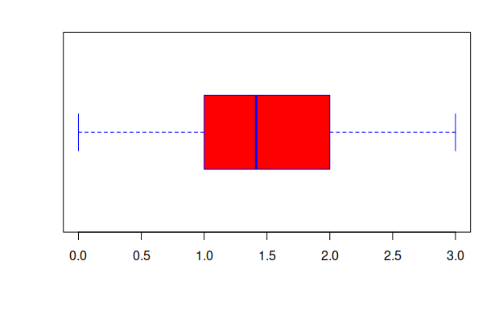

```r
boxplot(sqrt(emp_df$NumCompaniesWorked),range=1.5,col=c("red"),border=c("blue"),horizontal = TRUE)
```

For Percentage Salary Hike

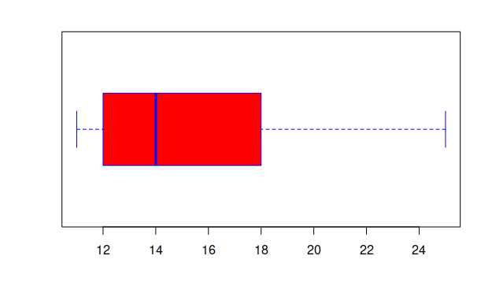

```r
boxplot(emp_df$PercentSalaryHike,range=1.5,col=c("red"),border=c("blue"),horizontal = TRUE)
```

For Total Working Years

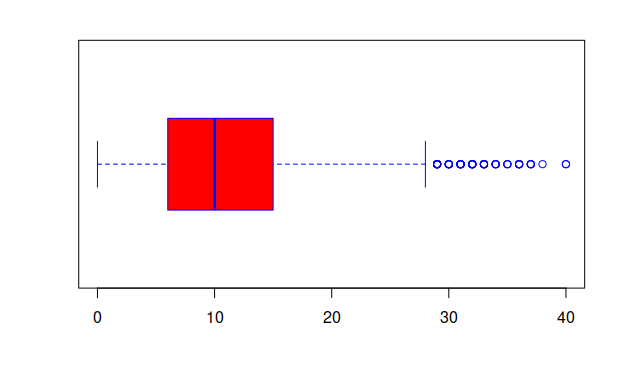

```r
boxplot(emp_df$TotalWorkingYears,range=1.5,col=c("red"),border=c("blue"),horizontal = TRUE)
```

The distribution of number of total working years

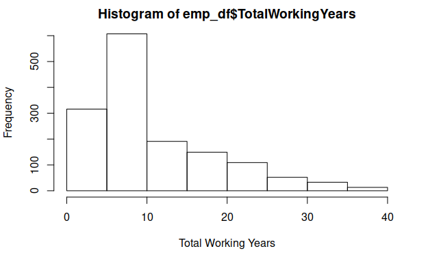

```r
hist(emp_df$TotalWorkingYears,xlab="Total Working Years")
```

Applying Square root transformation

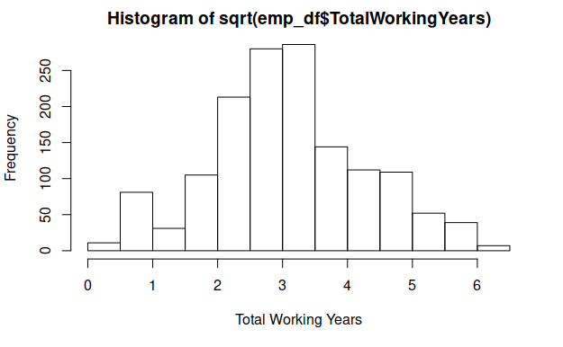

```r
hist(sqrt(emp_df$TotalWorkingYears) ,xlab="Total Working Years")
```

Squart Root Tranformation seems to convert the data into a normal distribution which removes the ouliers.

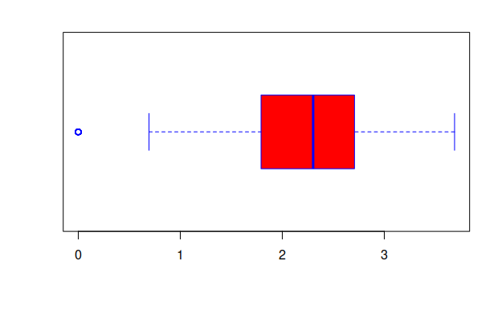

```r
boxplot(log(emp_df$TotalWorkingYears),range=1.5,col=c("red"),border=c("blue"),horizontal = TRUE)
```

Yet to Conclude. For Years At Company

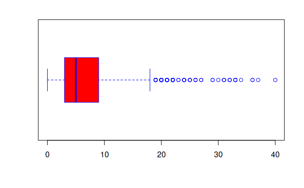

```r
boxplot(emp_df$YearsAtCompany,range=1.5,col=c("red"),border=c("blue"),horizontal = TRUE)
```

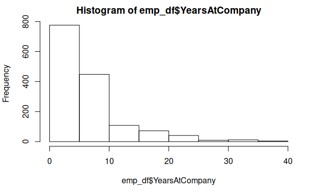

```r
hist(emp_df$YearsAtCompany)
```

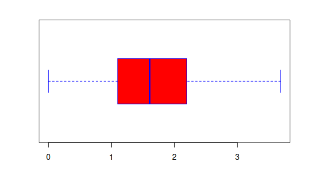

```r
boxplot(log(emp_df$YearsAtCompany),range=1.5,col=c("red"),border=c("blue"),horizontal = TRUE)
```

For Years in current role

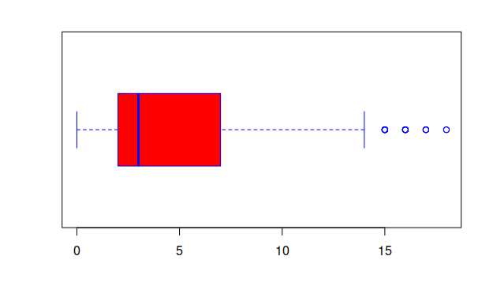

```r
boxplot(emp_df$YearsInCurrentRole,range=1.5,col=c("red"),border=c("blue"),horizontal = TRUE)
```

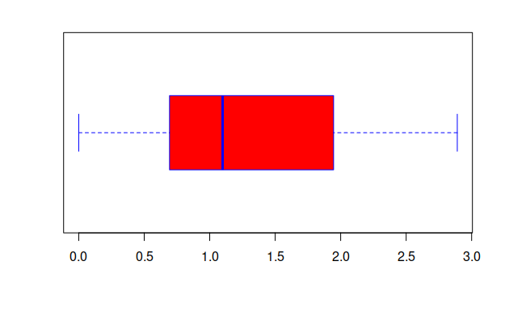

```r
boxplot(log(emp_df$YearsInCurrentRole),range=1.5,col=c("red"),border=c("blue"),horizontal = TRUE)
```

For Years Since Last Promotion

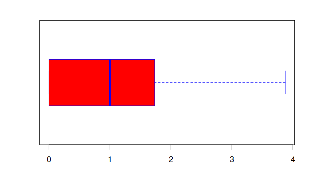

```r
boxplot(sqrt(emp_df$YearsSinceLastPromotion),range=1.5,col=c("red"),border=c("blue"),horizontal = TRUE)
```

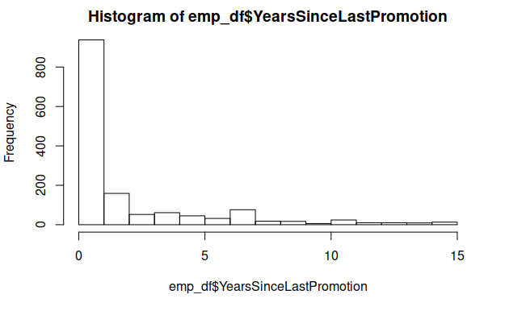

```r
hist(emp_df$YearsSinceLastPromotion)
```

```r
cor(emp_df$YearsSinceLastPromotion,emp_df$Attrition)
```

```
[1] -0.03301878
```

For Years With Current Manager

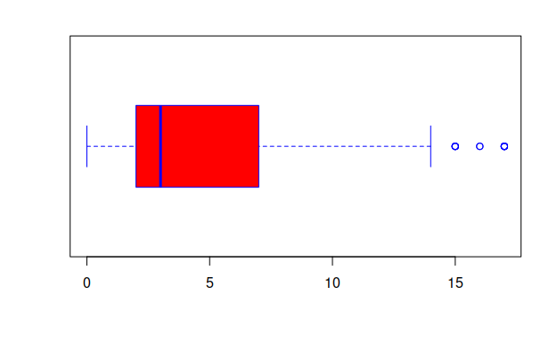

```r
boxplot(emp_df$YearsWithCurrManager,range=1.5,col=c("red"),border=c("blue"),horizontal = TRUE)
```

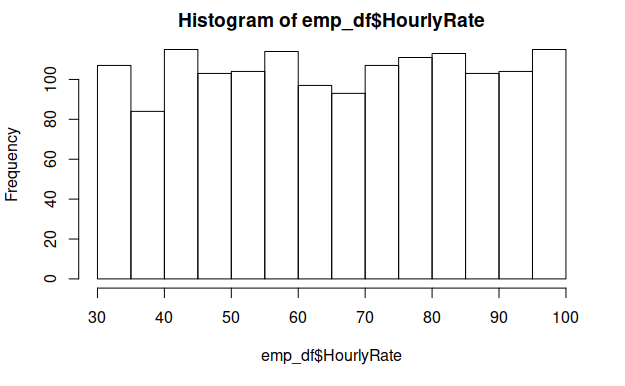

```r
hist(emp_df$HourlyRate)
```

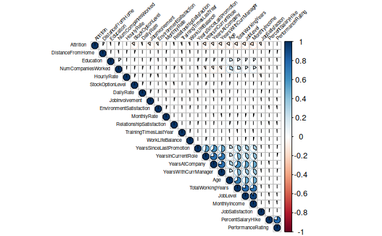

```r
library(corrplot)
corrplot(cor(select_if(emp_df,"is.numeric")),method="pie",type="upper",tl.col="black",order="hclust",tl.srt=45,tl.cex=0.5)
```

# Models

## Logistic Regression.

The categorical data must be encoded for the logistic regression model. The data tranformation are already performed earlier

```r
library(caret)
one_hot_emp_df<-dummyVars("~.",data=emp_df,fullRank=T)
one_hot_emp_df<-data.frame(predict(one_hot_emp_df,emp_df))
str(one_hot_emp_df)
```

```
'data.frame':   1470 obs. of  45 variables:
 $ Age                              : num  41 49 37 33 27 32 59 30 38 36 ...
 $ Attrition                        : num  1 0 1 0 0 0 0 0 0 0 ...
 $ BusinessTravel.Travel_Frequently : num  0 1 0 1 0 1 0 0 1 0 ...
 $ BusinessTravel.Travel_Rarely     : num  1 0 1 0 1 0 1 1 0 1 ...
 $ DailyRate                        : num  1102 279 1373 1392 591 ...
 $ Department.Research...Development: num  0 1 1 1 1 1 1 1 1 1 ...
 $ Department.Sales                 : num  1 0 0 0 0 0 0 0 0 0 ...
 $ DistanceFromHome                 : num  1 8 2 3 2 2 3 24 23 27 ...
 $ Education                        : num  2 1 2 4 1 2 3 1 3 3 ...
 $ EducationField.Life.Sciences     : num  1 1 0 1 0 1 0 1 1 0 ...
 $ EducationField.Marketing         : num  0 0 0 0 0 0 0 0 0 0 ...
 $ EducationField.Medical           : num  0 0 0 0 1 0 1 0 0 1 ...
 $ EducationField.Other             : num  0 0 1 0 0 0 0 0 0 0 ...
 $ EducationField.Technical.Degree  : num  0 0 0 0 0 0 0 0 0 0 ...
```

[output cut: 31 more lines]

Spliting the data

```r
split<-sample.int(nrow(emp_df),replace = FALSE,size=floor(0.8*nrow(emp_df)))
train_lr_data<-one_hot_emp_df[split,]
test_lr_data<-one_hot_emp_df[-split,]
```

Model Implementation

```r
lr_model<-glm(Attrition~.,train_lr_data,family = "binomial")
summary(lr_model)
```

```
Call:
glm(formula = Attrition ~ ., family = "binomial", data = train_lr_data)

Deviance Residuals:
    Min       1Q   Median       3Q      Max
-1.6736  -0.4795  -0.2495  -0.0894   3.5728

Coefficients:
                                    Estimate Std. Error z value Pr(>|z|)
(Intercept)                       -2.025e+00  7.006e+02  -0.003 0.997694
Age                               -4.975e-02  1.607e-02  -3.096 0.001959
BusinessTravel.Travel_Frequently   2.004e+00  4.840e-01   4.140 3.47e-05
BusinessTravel.Travel_Rarely       1.012e+00  4.522e-01   2.237 0.025276
DailyRate                         -4.061e-04  2.541e-04  -1.598 0.109949
Department.Research...Development  1.304e+01  7.006e+02   0.019 0.985151
Department.Sales                   1.330e+01  7.006e+02   0.019 0.984855
DistanceFromHome                   4.013e-02  1.223e-02   3.281 0.001034
Education                          7.227e-02  9.848e-02   0.734 0.463014
EducationField.Life.Sciences      -2.029e-01  1.005e+00  -0.202 0.839966
EducationField.Marketing           2.604e-01  1.055e+00   0.247 0.805034
EducationField.Medical            -1.958e-01  1.000e+00  -0.196 0.844801
EducationField.Other              -2.289e-01  1.091e+00  -0.210 0.833889
EducationField.Technical.Degree    1.006e+00  1.010e+00   0.997 0.318887
EnvironmentSatisfaction           -4.678e-01  9.536e-02  -4.905 9.32e-07
Gender.Male                        4.940e-01  2.118e-01   2.332 0.019705
HourlyRate                        -2.109e-06  4.986e-03   0.000 0.999663
JobInvolvement                    -5.509e-01  1.415e-01  -3.893 9.90e-05
JobLevel                           2.880e-01  3.106e-01   0.927 0.353719
JobRole.Human.Resources            1.391e+01  7.006e+02   0.020 0.984158
JobRole.Laboratory.Technician      8.490e-01  5.311e-01   1.599 0.109869
JobRole.Manager                    5.792e-01  9.493e-01   0.610 0.541804
JobRole.Manufacturing.Director     4.036e-01  5.486e-01   0.736 0.461981
JobRole.Research.Director         -1.542e+00  1.287e+00  -1.198 0.230810
JobRole.Research.Scientist        -1.783e-01  5.485e-01  -0.325 0.745153
JobRole.Sales.Executive            5.328e-01  1.228e+00   0.434 0.664330
JobRole.Sales.Representative       1.115e+00  1.291e+00   0.864 0.387734
JobSatisfaction                   -3.834e-01  9.262e-02  -4.139 3.48e-05
MaritalStatus.Married              1.336e-01  2.953e-01   0.452 0.651037
MaritalStatus.Single               6.628e-01  3.806e-01   1.741 0.081612
MonthlyIncome                     -9.730e-01  4.191e-01  -2.322 0.020239
```

[output cut: 55 more lines]

```
WorkLifeBalance                   *
YearsAtCompany
YearsInCurrentRole                *
YearsSinceLastPromotion           ***
YearsWithCurrManager              *
---
Signif. codes:  0 ‘***’ 0.001 ‘**’ 0.01 ‘*’ 0.05 ‘.’ 0.1 ‘ ’ 1

(Dispersion parameter for binomial family taken to be 1)

    Null deviance: 1020.20  on 1175  degrees of freedom
Residual deviance:  669.54  on 1131  degrees of freedom
AIC: 759.54

Number of Fisher Scoring iterations: 15
```

There are a lot of features with p-value as high as 0.1. Training Accuracy (Threshold=0.5)

```r
conf_matrix<-table(train_lr_data$Attrition,predict(lr_model,train_lr_data,type="response")>0.5)
print(conf_matrix)
```

```
    FALSE TRUE
  0   968   24
  1    99   85
```

```r
print(sum(diag(conf_matrix))/sum(conf_matrix))
```

```
[1] 0.8954082
```

```r
library(ROCR)
roc_predcition<-prediction(predict(lr_model,test_lr_data,type="response"),test_lr_data$Attrition)
AUC<-performance(roc_predcition,measure="auc")@y.values[[1]]
print(AUC)
```

```
[1] 0.8569639
```

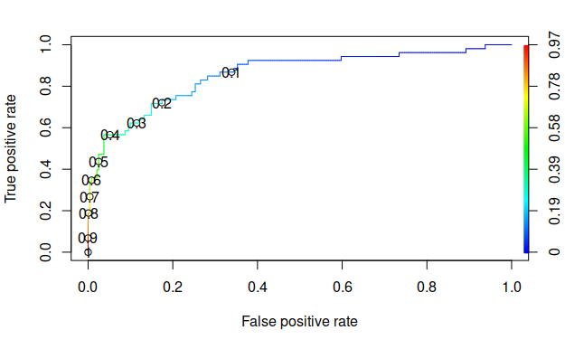

```r
roc_performace<-performance(roc_predcition,"tpr","fpr")
plot(roc_performace,colorize=1,print.cutoffs.at=seq(0.1,by=(0.1)))
```

Testing the model

```r
conf_matrix<-table(test_lr_data$Attrition,predict(lr_model,test_lr_data,type="response")>0.6)
print(conf_matrix)
```

```
    FALSE TRUE
  0   239    2
  1    35   18
```

```r
print(sum(diag(conf_matrix))/sum(conf_matrix))
```

```
[1] 0.8741497
```

Selected features model

```r
sf_emp_df<-select(one_hot_emp_df,-c("Department.Research...Development"
,"Department.Sales"
,"EducationField.Life.Sciences"
,"EducationField.Marketing"
,"EducationField.Medical"
,"EducationField.Other"
,"EducationField.Technical.Degree"
,"JobRole.Human.Resources"
,"JobRole.Laboratory.Technician"
,"JobRole.Manager"
,"JobRole.Manufacturing.Director"
,"JobRole.Research.Director"
,"JobRole.Research.Scientist"
,"JobRole.Sales.Executive"
,"JobRole.Sales.Representative"))
sf_train_lr_data<-sf_emp_df[split,]
sf_test_lr_data<-sf_emp_df[-split,]
sf_lr_model<-glm(Attrition~.,sf_train_lr_data,family = "binomial")
summary(sf_lr_model)
```

```
Call:
glm(formula = Attrition ~ ., family = "binomial", data = sf_train_lr_data)

Deviance Residuals:
    Min       1Q   Median       3Q      Max
-1.7969  -0.5144  -0.2763  -0.1167   3.6410

Coefficients:
                                   Estimate Std. Error z value Pr(>|z|)
(Intercept)                       1.123e+01  3.103e+00   3.619 0.000295
Age                              -4.684e-02  1.560e-02  -3.002 0.002681
BusinessTravel.Travel_Frequently  2.013e+00  4.701e-01   4.283 1.85e-05
BusinessTravel.Travel_Rarely      1.110e+00  4.392e-01   2.527 0.011512
DailyRate                        -3.366e-04  2.437e-04  -1.381 0.167203
DistanceFromHome                  3.575e-02  1.163e-02   3.074 0.002112
Education                         3.873e-02  9.348e-02   0.414 0.678670
EnvironmentSatisfaction          -4.294e-01  9.103e-02  -4.717 2.39e-06
Gender.Male                       5.063e-01  2.035e-01   2.487 0.012874
HourlyRate                       -7.641e-04  4.798e-03  -0.159 0.873467
JobInvolvement                   -5.938e-01  1.354e-01  -4.386 1.15e-05
JobLevel                          3.461e-01  2.607e-01   1.328 0.184342
JobSatisfaction                  -3.897e-01  8.903e-02  -4.377 1.20e-05
MaritalStatus.Married             1.239e-01  2.861e-01   0.433 0.664889
MaritalStatus.Single              6.921e-01  3.615e-01   1.915 0.055522
MonthlyIncome                    -9.908e-01  3.689e-01  -2.686 0.007226
MonthlyRate                      -4.840e-07  1.367e-05  -0.035 0.971761
NumCompaniesWorked                1.761e-01  4.295e-02   4.100 4.12e-05
OverTime.Yes                      1.825e+00  2.086e-01   8.750  < 2e-16
PercentSalaryHike                -1.823e-02  4.260e-02  -0.428 0.668764
PerformanceRating                -1.125e-02  4.381e-01  -0.026 0.979511
RelationshipSatisfaction         -2.877e-01  9.068e-02  -3.173 0.001508
StockOptionLevel                 -3.096e-01  1.669e-01  -1.855 0.063559
TotalWorkingYears                -6.257e-02  3.116e-02  -2.008 0.044660
TrainingTimesLastYear            -1.523e-01  7.826e-02  -1.946 0.051608
WorkLifeBalance                  -2.201e-01  1.344e-01  -1.638 0.101524
YearsAtCompany                    5.298e-02  4.295e-02   1.234 0.217346
YearsInCurrentRole               -1.067e-01  5.048e-02  -2.114 0.034514
YearsSinceLastPromotion           1.654e-01  4.678e-02   3.537 0.000405
YearsWithCurrManager             -1.137e-01  5.193e-02  -2.190 0.028518

```

[output cut: 25 more lines]

```
WorkLifeBalance
YearsAtCompany
YearsInCurrentRole               *
YearsSinceLastPromotion          ***
YearsWithCurrManager             *
---
Signif. codes:  0 ‘***’ 0.001 ‘**’ 0.01 ‘*’ 0.05 ‘.’ 0.1 ‘ ’ 1

(Dispersion parameter for binomial family taken to be 1)

    Null deviance: 1020.20  on 1175  degrees of freedom
Residual deviance:  714.84  on 1146  degrees of freedom
AIC: 774.84

Number of Fisher Scoring iterations: 6
```

```r
sf_conf_matrix<-table(sf_test_lr_data$Attrition,predict(sf_lr_model,sf_test_lr_data,type="response")>0.5)
print(sf_conf_matrix)
```

```
    FALSE TRUE
  0   235    6
  1    30   23
```

```r
print(sum(diag(sf_conf_matrix))/sum(sf_conf_matrix))
```

```
[1] 0.877551
```

There is no significant difference between the two models. Training time may reduce. Feature Importance.

```r
coeff<-summary(lr_model)$coefficients
coeff<-data.frame(coeff[,0],coeff[,1])
coeff<-tibble::rownames_to_column(coeff,"term")
names(coeff)<-c("Coefficient","Estimate")
rownames(coeff)<-coeff$Coefficient
coeff<-subset(coeff,!(row.names(coeff) %in%c("Department.Research...Development"
,"Department.Sales"
,"EducationField.Life.Sciences"
,"EducationField.Marketing"
,"EducationField.Medical"
,"EducationField.Other"
,"EducationField.Technical.Degree"
,"JobRole.Human.Resources"
,"JobRole.Laboratory.Technician"
,"JobRole.Manager"
,"JobRole.Manufacturing.Director"
,"JobRole.Research.Director"
,"JobRole.Research.Scientist"
,"JobRole.Sales.Executive"
,"JobRole.Sales.Representative","(Intercept)","MaritalStatus.Single","MaritalStatus.Married","DailyRate"
,"Gender.Male"
,"MonthlyRate","HourlyRate","BusinessTravel.Travel_Frequently","BusinessTravel.Travel_Rarely")))
```

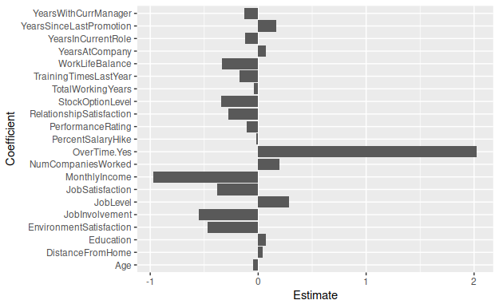

```r
ggplot(coeff,aes(Coefficient,Estimate))+geom_bar(stat="identity")+coord_flip()
```

From the Logistic Regression Model, Over Time is identified as the most contributing factor to Employee Attrition. Monthly Income is the most weighted negative factor, so a higher monthly income can reduce employee attrition. Job Involvement, Environment Satisfaction and Work LIfe Balance Seems to a have positive effect on reducing employee attrition.

# Decision Tree.

```r
split<-sample.int(nrow(emp_df),size=floor(0.8*nrow(emp_df)),replace=FALSE)
train_dt_data<-emp_df[split,]
test_dt_data<-emp_df[-split,]
```

[figure not shown]

```r
library(party)
dt_model<-ctree(Attrition~.,train_dt_data)
plot(dt_model)
```

Training Accuracy (Threshold=0.5)

```r
conf_matrix<-table(train_dt_data$Attrition,predict(dt_model,train_dt_data,type="response")>0.5)
print(conf_matrix)
```

```
    FALSE TRUE
  0   972   19
  1   129   56
```

```r
print(sum(diag(conf_matrix))/sum(conf_matrix))
```

```
[1] 0.8741497
```

```r
library(ROCR)
roc_predcition<-prediction(predict(dt_model,test_dt_data,type="response"),test_dt_data$Attrition)
AUC<-performance(roc_predcition,measure="auc")@y.values[[1]]
print(AUC)
```

```
[1] 0.6701367
```

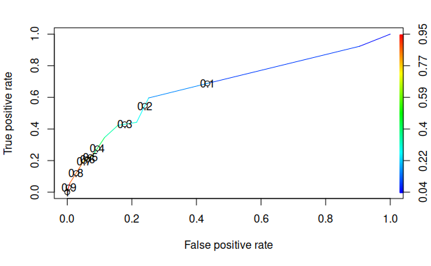

```r
roc_performace<-performance(roc_predcition,"tpr","fpr")
plot(roc_performace,colorize=1,print.cutoffs.at=seq(0.1,by=(0.1)))
```

Testing Accuracy (Threshold=0.5)

```r
conf_matrix<-table(test_dt_data$Attrition,predict(dt_model,test_dt_data,type="response")>0.5)
print(conf_matrix)
```

```
    FALSE TRUE
  0   233   14
  1    33   14
```

```r
print(sum(diag(conf_matrix))/sum(conf_matrix))
```

```
[1] 0.8401361
```

```r
summary(dt_model)
```

```
    Length      Class       Mode
         1 BinaryTree         S4
```